# Case Study 1

McKay Davis

## The Richest States in the USA

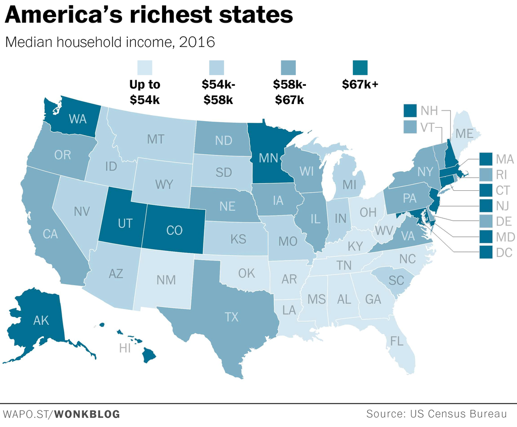

The Good: This graphic is very easy to interpret. You don’t even have to look at the key to know that darker means higher income due to the natural rankings of lighter to darker hues. There aren’t any distracters in the graphic.

The Bad: While it is obvious from the plot which states have the higher median household income, it isn’t obvious at all which state’s median income is higher than all the rest. The purpose of the article was to show the very richest state. The graphic doesn’t do such a good job at this due to the interval system used to rank incomes. Another shortcoming of the graphic is that it fails to use consistent intervals in income categories. There doesn’t appear to be any rhyme or reason to the intervals chosen. Further, it gives no reason for defining the richest states as those with $67,000 and up median household income.

## Favorite Fresh Produce in the Workplace

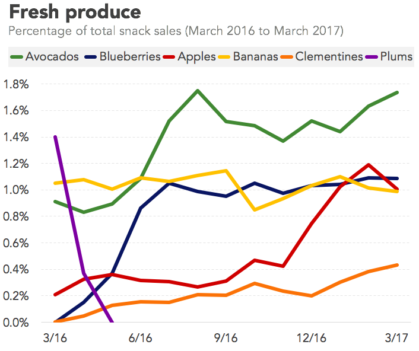

The Good: This plot is color coded! That makes it very readable. The plot shows the general idea of which fresh produce is most popular for office snacks. The plot spans a full year, which may indicate that the produce highs and lows are not due to season. The percentage of total snack sales goes up by an even interval and begins at zero. Gridlines are non-obvious but present.

The Bad: The issue isn’t really in the graphic, the graphic really seems quite good for its purpose. The issue is in the data. More data would be far more descriptive of the trend.

## How Smiley Are Employees of Some Countries on LinkedIn

[figure not shown]

The Good: The graphic uses color well in that red is naturally bad and blue is good and the more intense the color the the more intensely “good” or “bad”.

The Bad: There is no legend! You just have to assume what the colors mean. This makes a serious deficit in understandability of the graphic. I think the countries also need to be labeled. It would make it overall much more readable.

[figure not shown]

```r
plot(1:20)
```